*“Universidad UTEC”*

1.Introducción

### 1.1. Relevancia

La música ha sido parte de la cultura humana desde hace más de miles de años. Es difícil encontrar alguna cultura antigua que no tenga alguna forma de música integrada en alguna actividad. Danzas tribales, los cantares de gesta, los conciertos comisionados por hombres opulentos, la música popular del ultimo ciclo, todas estas son parte de la cultura de su tiempo. Hoy nos vamos a centrar en este último, específicamente en la década del 2010. Usando los datos extraídos de Spotify, uno de los servicios de streaming de música más grande del mundo, queremos encontrar si hay alguna tendencia en los detalles técnicos,específicamente los decibeles y los beats por minuto en los hits de la década del 2010. Es posible que ahora con el acceso popular a la música, el público haya tendido a un cierto bpm indirectamente.

Un claro ejemplo es que la música ha sido parte de la cultura humana desde hace más de miles de años. Es difícil encontrar alguna cultura antigua que no tenga alguna forma de música integrada en alguna actividad. Danzas tribales, los cantares de gesta, los conciertos comisionados por hombres opulentos, la música popular del ultimo ciclo, todas estas son parte de la cultura de su tiempo. Hoy nos vamos a centrar en este último, específicamente en la década del 2010. Usando los datos extraídos de Spotify, uno de los servicios de streaming de música más grande del mundo, queremos encontrar si hay alguna tendencia en cosas como el género, los beats por minuto, o la duración en los hits de la década del 2010.

Además, utilizando la función **`nrow()`** contamos la cantidad de observaciones (filas) de nuestra base de datos y utilizando la función **`ncol()`** podremos contar la cantidad de variables (columnas).

```r
library(readr)
library(dplyr)
DFL<-read.csv( "Base de datos Limpia.csv")
```

```r
n_observaciones <- nrow(DFL)
n_variables <- ncol(DFL)
```

Es así que calculamos la existencia de **1000 observaciones y 7 variables.**

### 1.2. Planificación

```r
ifelse(require(readr)==T, library(readr))
```

```
## [1] "dplyr"
```

```r
ifelse(require(ggplot2)==T, library(ggplot2))
```

```
## [1] "ggplot2"
```

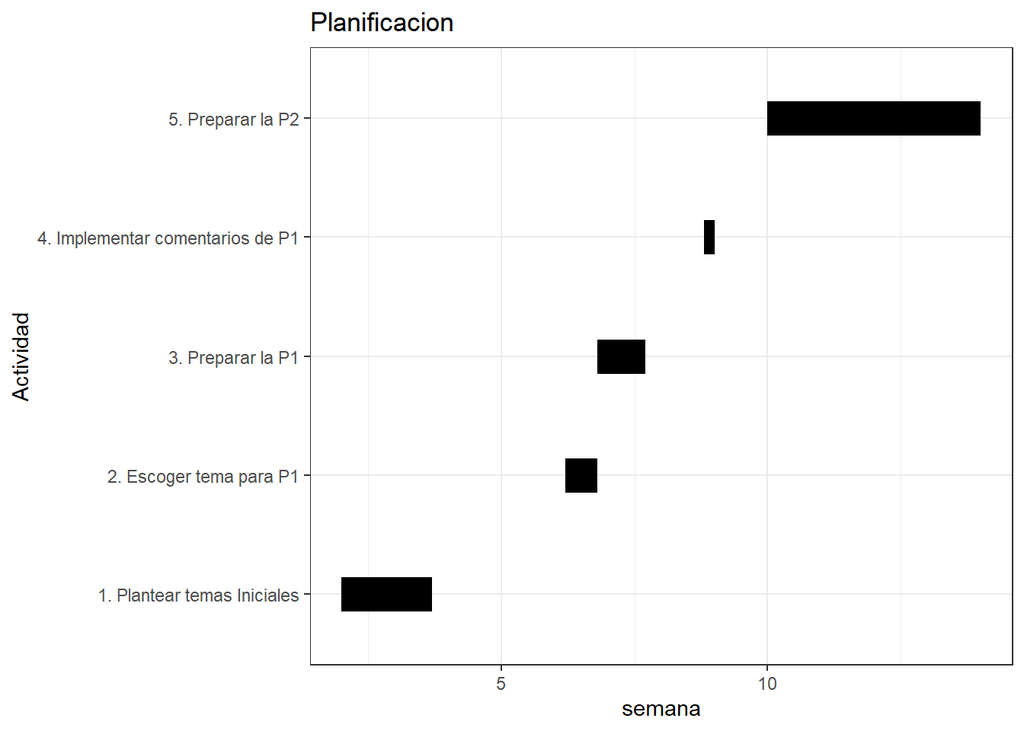

```r
a <-('1. Plantear temas Iniciales')
b <- ('2. Escoger tema para P1')
c <- ('3. Preparar la P1')
d <- ('4. Implementar comentarios de P1')
e <- ('5. Preparar la P2')
plan <- data.frame(Actividad = c(a, b, c, d, e),
start = c(2, 6.2, 6.8, 8.8, 10),
end = c(3.7, 6.8, 7.7, 9, 14)
)

if(!require(ggplot2)){install.packages('ggplot2')}

ggplot(plan, aes(x=start, xend=end, y=Actividad, yend=Actividad )) +
  theme_bw()+ #use ggplot theme with black gridlines and white background
  geom_segment(size=8) + #increase line width of segments in the chart
  labs(title='Planificacion', x='semana', y='Actividad')
```

## Datos

### 2.1. Recolección de datos

La recolección de datos se basa en una “playlist” creada por la propia plataforma de Spotify del ranking de top 100 canciones más escuchadas de todos los años desde el 2010 hasta el 2019, este ranking se basa en el número de reproducciones de las canciones por año, cada reproducción cuenta si cualquier usuario escucha como mínimo 30 segundos de la canción. Las otras variables se consiguieron usando una página creada también por Spotify llamada “Organise your music”. Está página se usó en cada playlist y se logró obtener los datos de género, estado de ánimo, estilo, década, año de aparición, duración, popularidad, etc. Como la página pertenece a la propia compañía de “streaming”, cuenta con toda la información de las canciones y los artistas, de esta manera consigue los datos numéricos y categóricos más sencillos como el nombre de la canción y del artista, la duración de la canción, el género señalado por el artista, los decibelios (intensidad de sonido), los “beats per minute” (duración de notas/velocidad), entre otros. Además de estas variables fáciles de reconocer, tambien brinda otras como “Estado de ánimo” o “Estilo” las cuales Spotify determinada a través de un IA que usa “big data” y “machine Learning” para analizar las pistas de audio todavía no procesadas para poder clasificarlas en las distintas categorías.

[figure not shown]

### 2.2. Población, muestra y muestreo

Nuestra población son todas las canciones más populares de Spotify. Además, hemos decidido solo trabajar con las Top 100 canciones por año desde 2010 a 2019, esta data frame la hemos obtenido de las playlist de Spotify. Por otro lado, este muestreo es intencional y determinado por las propias estrategias que tiene Spotify para reconocer un Hits de canciones.

### 2.3. Variables

| Variable | Tipo de Variable | Restricciones |
| --- | --- | --- |
| Título | Categórica Nominal | Nombre de la canción |
| Artista | Categórica Nominal | Nombre del artista |
| Género | Categórica Nominal | género de la canción |
| Bpm | Numérica discreta | Número de beats por minuto |
| dB | Numérica discreta | Número de decibelios de la música |
| Duración | Numérica discreta | Número de segundos que dura la canción |
| Top Year | Categórica Nominal | Años [2010 ; 2019] |

### 2.4. Limpieza de base de datos

En este apartado lo que se busca es dejar de lado las variables que no utilizaremos para el proyecto con el objetivo de que podamos quedarnos con las variables relevantes para el análisis. Entonces, para hacer la limpieza primero cargamos las librerías y la información (Data frame) que necesitaremos para nuestra base de datos:

```r
ifelse(require(readr)==T, library(readr))
```

```
## [1] "ggplot2"
```

```r
DF = read_csv("Spotify 2010 - 2019 Top 100.csv")
```

Lo primero que debemos “limpiar” son aquellas variables que no nos servirán para nuestro objetivo, estas son: Year released, added, nrgy, dnce, live, val, acous, spch, pop, artis type. Para esto llamaremos a todas las variables que tenemos para conocer los indices de cada una. Posteriormente las eliminamos una a una.

```r
variables <- colnames(DF)
DF1 <- DF[,-4] # Elimina Year realeased
DF2 <- DF1[,-4] # Elimina added
DF3 <- DF2[,-5] # Elimina nrgy
DF4 <- DF3[,-5] # Elimina dnce
DF5 <- DF4[,-6] # Elimina live
DF6 <- DF5[,-6] # Elimina val
DF7 <- DF6[,-7] # Elimina acous
DF8 <- DF7[,-7] # Elimina soch
DF9 <- DF8[,-7] # Elimina pop
DFL <- DF9[,-8] # Elimina artis type
DFL
```

| title | artist | top genre | bpm | dB | dur | top year |
| --- | --- | --- | --- | --- | --- | --- |
| STARSTRUKK (feat. Katy Perry) | 3OH!3 | dance pop | 140 | -6 | 203 | 2010 |
| My First Kiss (feat. Ke$ha) | 3OH!3 | dance pop | 138 | -4 | 192 | 2010 |
| I Need A Dollar | Aloe Blacc | pop soul | 95 | -7 | 243 | 2010 |
| Airplanes (feat. Hayley Williams of Paramore) | B.o.B | atl hip hop | 93 | -4 | 180 | 2010 |
| Nothin' on You (feat. Bruno Mars) | B.o.B | atl hip hop | 104 | -6 | 268 | 2010 |
| Magic (feat. Rivers Cuomo) | B.o.B | atl hip hop | 82 | -4 | 196 | 2010 |
| The Time (Dirty Bit) | Black Eyed Peas | dance pop | 128 | -8 | 308 | 2010 |
| Imma Be | Black Eyed Peas | dance pop | 92 | -7 | 258 | 2010 |
| Talking to the Moon | Bruno Mars | dance pop | 146 | -5 | 218 | 2010 |
| Just the Way You Are | Bruno Mars | dance pop | 109 | -5 | 221 | 2010 |

[output cut: 993 more lines]

Una vez se tenga la base de datos con las variables que vamos a usar procederemos a buscar datos incompletos:

```r
#Verificaremos que el archivo no cuente con datos faltantes
Na1 = sum((is.na(DFL$title)))
Na2 = sum((is.na(DFL$artist)))
Na3 = sum((is.na(DFL$`top genre`)))
Na4 = sum((is.na(DFL$bpm)))
Na5 = sum((is.na(DFL$dB)))
Na6 = sum((is.na(DFL$dur)))
Na7 = sum((is.na(DFL$`top year`)))

#Nos indica que tenemos 3 valores N.A a lo último de la tabla, los eliminamos.
DFL = head(DFL, 1000)
DFL
```

| title | artist | top genre | bpm | dB | dur | top year |
| --- | --- | --- | --- | --- | --- | --- |
| STARSTRUKK (feat. Katy Perry) | 3OH!3 | dance pop | 140 | -6 | 203 | 2010 |
| My First Kiss (feat. Ke$ha) | 3OH!3 | dance pop | 138 | -4 | 192 | 2010 |
| I Need A Dollar | Aloe Blacc | pop soul | 95 | -7 | 243 | 2010 |
| Airplanes (feat. Hayley Williams of Paramore) | B.o.B | atl hip hop | 93 | -4 | 180 | 2010 |
| Nothin' on You (feat. Bruno Mars) | B.o.B | atl hip hop | 104 | -6 | 268 | 2010 |
| Magic (feat. Rivers Cuomo) | B.o.B | atl hip hop | 82 | -4 | 196 | 2010 |
| The Time (Dirty Bit) | Black Eyed Peas | dance pop | 128 | -8 | 308 | 2010 |
| Imma Be | Black Eyed Peas | dance pop | 92 | -7 | 258 | 2010 |
| Talking to the Moon | Bruno Mars | dance pop | 146 | -5 | 218 | 2010 |
| Just the Way You Are | Bruno Mars | dance pop | 109 | -5 | 221 | 2010 |

[output cut: 990 more lines]

Ahora sí ya tenemos la base de datos limpia. Como bien sabemos contamos con un ranking de 100 canciones por año, desde el 2010 al 2019. En nuestro caso, además de desarrollar la base de datos general DFL (Data frame Limpia), como también queremos observar un análisis por año, hemos creado variables las cuales contendrán los diferentes stacks (100 canciones por año).

```r
#Selección canciones de cada año
TOP2010 <- DFL[!(DFL$`top year` > 2010),]

TOP2011 <- DFL[(DFL$`top year` == 2011),]

TOP2012 <- DFL[(DFL$`top year` == 2012),]

TOP2013 <- DFL[(DFL$`top year` == 2013),]

TOP2014 <- DFL[(DFL$`top year` == 2014),]

TOP2015 <- DFL[(DFL$`top year` == 2015),]

TOP2016 <- DFL[(DFL$`top year` == 2016),]

TOP2017 <- DFL[(DFL$`top year` == 2017),]

TOP2018 <- DFL[(DFL$`top year` == 2018),]

TOP2019 <- DFL[(DFL$`top year` == 2019),]
```

Una vez tenemos los stacks, procederemos a crear archivos correspondientes a ellos; es decir, tendremos 10 archivos los cuales cada uno representan las 100 canciones de cada año. Para hacerlo posible hemos desarrollado el siguiente código:

```r
#Crea base de datos limpia por cada año
write_csv(TOP2010, "TOP100_2010.csv")
write_csv(TOP2011, "TOP100_2011.csv")
write_csv(TOP2012, "TOP100_2012.csv")
write_csv(TOP2013, "TOP100_2013.csv")
write_csv(TOP2014, "TOP100_2014.csv")
write_csv(TOP2015, "TOP100_2015.csv")
write_csv(TOP2016, "TOP100_2016.csv")
write_csv(TOP2017, "TOP100_2017.csv")
write_csv(TOP2018, "TOP100_2018.csv")
write_csv(TOP2019, "TOP100_2019.csv")

#Base de datos limpia con todos los años
write_csv(DFL, "Base de Datos Limpia.csv")
```

Una vez tenemos los archivos, nos encontramos listos para poder trabajar la data frame.

## Análisis Descriptivo

### 3.1. Artísta

```r
ifelse(require(readr)==T, library(readr))
```

```
## [1] "ggplot2"
```

```r
DD = read_csv("Base de Datos Limpia.csv")
Frecuencia_artista <- table(DD$artist)
Frecuencia_artista
```

```
##
##                 2 Chainz                21 Savage                    3OH!3
##                        2                        2                        2
##      5 Seconds of Summer                  6ix9ine   A Boogie Wit da Hoodie
##                        4                        2                        3
##                A$AP Ferg               A$AP Rocky             Adam Lambert
##                        1                        1                        1
##                    Adele                AJ Tracey                      AJR
##                        7                        1                        1
##             Alessia Cara                   Alesso               Alex Clare
##                        2                        2                        1
##           Alexandra Stan               Aloe Blacc                    alt-J
##                        1                        2                        1
##         American Authors                    Aminé             Andy Grammer
##                        1                        1                        1
##               Anne-Marie                 Anuel AA           Arctic Monkeys
##                        1                        2                        3
##            Ariana Grande              Asaf Avidan                 Ashley O
##                       14                        1                        1
##                 Astrid S                   Avicii            Avril Lavigne
##                        1                        7                        2
##               AWOLNATION      Axwell /\\ Ingrosso                Ayo & Teo
##                        1                        1                        1
##            Azealia Banks                  B Young                    B.o.B
##                        1                        1                        4
##                   Baauer                Bad Bunny           Bad Meets Evil
##                        1                        2                        1
##              Banx & Ranx                 Bastille                    Bazzi
##                        1                        3                        1
##                  Becky G             benny blanco                  Beyoncé
##                        1                        1                        5
##                 Big Sean                 Big Shaq            Billie Eilish
##                        2                        1                        6
##            Bingo Players                    Birdy          Black Eyed Peas
##                        1                        1                        3
##                blackbear                BLACKPINK            Blake Shelton
##                        1                        1                        2
##             Blanco Brown               BlocBoy JB                 Blueface
##                        1                        1                        1
##            Bobby Shmurda                 Bon Iver                    BØRNS
```

[output cut: 242 more lines]

```
##                        1                        6                        2
##        Waka Flocka Flame                     Wale            WALK THE MOON
##                        2                        1                        2
##                    Wiley                will.i.am              Wiz Khalifa
##                        1                        2                        4
##            X Ambassadors             XXXTENTACION            Years & Years
##                        4                        4                        2
##                       YG                    Ylvis                 Yo Gotti
##                        1                        1                        1
##          Yolanda Be Cool              Young Money         Young T & Bugsey
##                        1                        1                        1
##               Young Thug             Zara Larsson           Zay Hilfigerrr
##                        1                        2                        1
##                     ZAYN                     Zedd                      ZHU
##                        1                        5                        1
```

La mayoría de los artistas no hacen más de una aparición entre todos los años. Aquellos que hacen más de una aparición suelen tenerlas en el mismo año o bien cerca entre sí, normalmente coincidiendo con un lanzamiento de un album y/o un Single de ese album. Por ejemplo, La banda Arctic Monkeys, que apareció un total de 3 veces, tuvo dos hits en el 2013 y uno en el 2012, todos de su albúm “AM”, y “R U Mine?”, su hit del 2012, fue un single del albúm que salió un año antes. La artista con más apariciónes en total es Taylor Swift, con un total de 21 hits en la decada, y es la única artista en tener una canción que aparece en la lista en dos años diferentes, siendo esta “Bad Blood” en los años 2014 y 2015.

### 3.2. Género

-Para analizar las variables primero cargaremos las librerias que vayamos a utilizar

```r
ifelse(require(readr)==T, library(readr))
```

```
## [1] "ggplot2"
```

```r
ifelse(require(dplyr)==T, library(dplyr))
```

```
## [1] "ggplot2"
```

-Para analizar la variable “género musical”, inciaremos por cargar la información

```r
BDL= read_csv("Base de Datos Limpia.csv")
```

y luego calculamos el género que más se repite entre todos los años (moda).

```r
#Moda

#Total BDL
dt= as.data.frame(table(BDL$`top genre`))
names(dt) = c("Géneros","# de canciones")
dt
```

| Géneros | # de canciones |
| --- | --- |
| acoustic pop | 1 |
| adult standards | 1 |
| afro dancehall | 1 |
| afrofuturism | 1 |
| afroswing | 4 |
| alt z | 8 |
| alternative dance | 4 |
| alternative metal | 2 |
| alternative pop rock | 1 |
| alternative r&b | 5 |

[output cut: 122 more lines]

Vemos que la moda es dance pop, con 361 canciones, las cuales son:

```r
#Vemos que la moda es dance pop
cmt=BDL[BDL$`top genre`=="dance pop",] #canciones con dance pop
cmt
```

| title | artist | top genre | bpm | dB | dur | top year |
| --- | --- | --- | --- | --- | --- | --- |
| STARSTRUKK (feat. Katy Perry) | 3OH!3 | dance pop | 140 | -6 | 203 | 2010 |
| My First Kiss (feat. Ke$ha) | 3OH!3 | dance pop | 138 | -4 | 192 | 2010 |
| The Time (Dirty Bit) | Black Eyed Peas | dance pop | 128 | -8 | 308 | 2010 |
| Imma Be | Black Eyed Peas | dance pop | 92 | -7 | 258 | 2010 |
| Talking to the Moon | Bruno Mars | dance pop | 146 | -5 | 218 | 2010 |
| Just the Way You Are | Bruno Mars | dance pop | 109 | -5 | 221 | 2010 |
| Deuces (feat. Tyga & Kevin McCall) | Chris Brown | dance pop | 74 | -5 | 277 | 2010 |
| All I Do Is Win (feat. T-Pain, Ludacris, Snoop Dogg & Rick Ross) | DJ Khaled | dance pop | 150 | -4 | 233 | 2010 |
| Starry Eyed | Ellie Goulding | dance pop | 150 | -5 | 177 | 2010 |
| I Like It | Enrique Iglesias | dance pop | 129 | -3 | 232 | 2010 |

[output cut: 351 more lines]

-Ahora que sabemos que el género modal es “dance pop”, y tenemos los datos, podemos ponerlos en una gráfica para observarlos mejor.

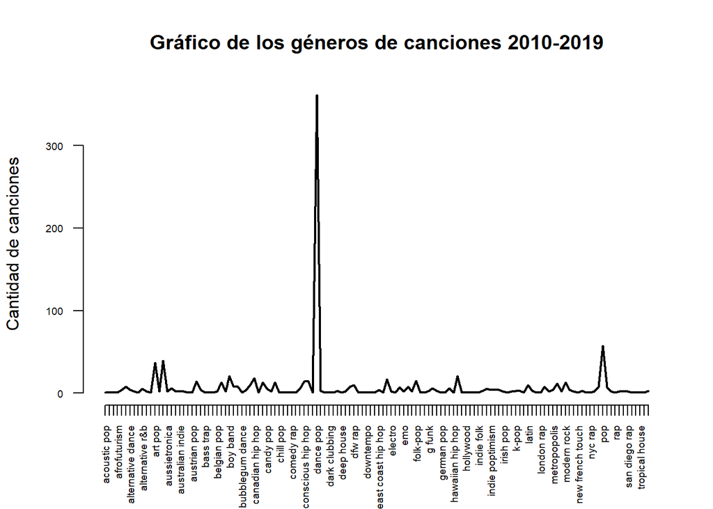

```r
#Gráfico de modas de género por año

#Total
plot(table(BDL$`top genre`),type="l",main="Gráfico de los géneros de canciones 2010-2019",ylab="Cantidad de canciones",las=2,cex.axis=0.6)
```

En esta gáfica se logra aprecia de una mejor manera como predomina el género “dance pop” en este top hits por encima de todas los otros géneros

¿Cómo es la aparición de este género por año? Primero guardamos la información que usaremos

```r
#Gráfico de "dance pop" por apariciones por año

a=BDL[BDL$`top genre`=="dance pop",]$`top genre`
b=BDL[BDL$`top genre`=="dance pop",]$`top year`
t=table(a,b)
```

Entonces el gráfico de # de apariciones sería:

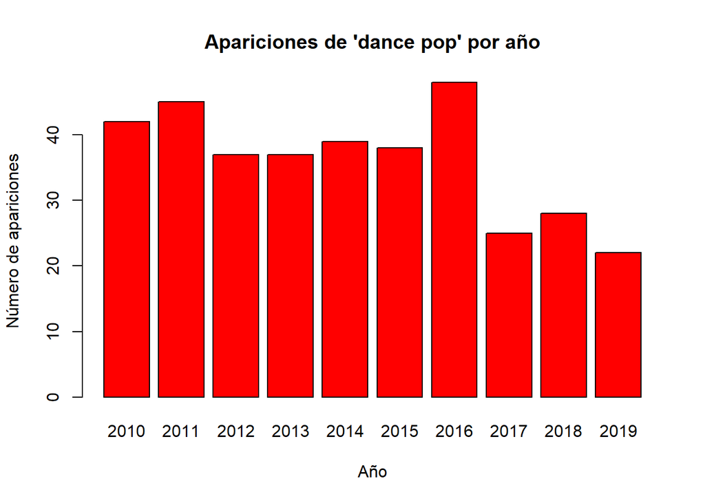

```r
barplot(t,col="red",main="Apariciones de 'dance pop' por año",ylab="Número de apariciones",xlab="Año")
```

Si lo pasamos a porcentajes…

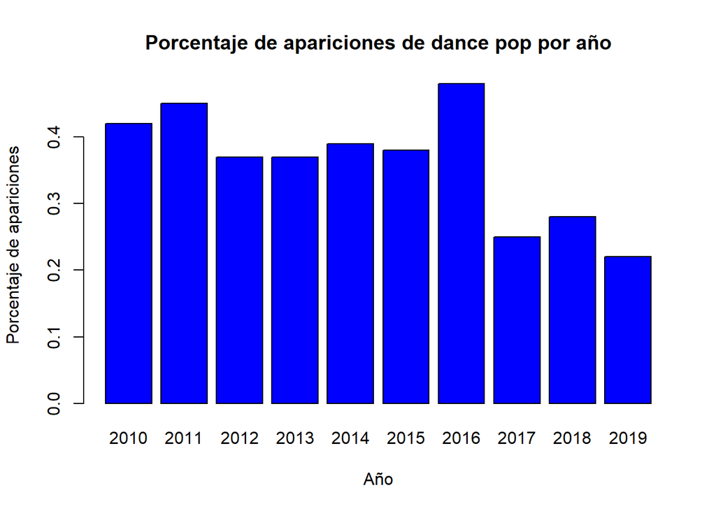

```r
barplot(t/100,col="blue", main="Porcentaje de apariciones de dance pop por año", ylab="Porcentaje de apariciones",xlab="Año")
```

Pero ¿Qué caracteriza al dance pop?

Para responder a esto vamos a utilizar las otras variables que tenemos: duración y BPM.

Género x BPM